# Structural equation occupancy simulation

From: Can marmots and pika take the heat? Structural equation occupancy models shed light on species persistence.

J. Wall

Last Updated: Feb. 13, 2024

### Background

This simulation is part of a larger project examining the impacts of global climate disruption on alpine wildlife in Alaska, specifically collared pika (*Ochotona collaris*), hoary marmots (*Marmota caligata*), and Arctic ground squirrels (*Urocitellus parryii*).

Here, we are simulating a Bayesian causal structural equation occupancy model, which uses multiple equations to represent relationships between observed and latent variables while simultaneously accounting for imperfect detection of species, which can bias results. For each model, we treat occurrence as a binary latent variable, Z, such that Z = 1 if a site, i, is occupied and Z = 0 if the site is unoccupied. We then calculate Z with a Bernoulli distribution of the probability of occurrence, $\psi$. We accounted for imperfect detection by modeling our site occurrence data, y, as a function of both Z and the probability of detection, p. As an alternative to repeated site visits for the occupancy model, we are instead calculating detection probabilities using 3-4 different sign types from our focal species. We consider a site occupied if only one of the sign types was detected in an area.

We have based this example off our 2022 data on collared pika, which encompasses 86 different site surveys with four different types of detection: individual sightings, vocalizations, scat, and haypiles.

### Setting up the data

First, let’s import all necessary libraries. If you don’t have any of these, you will need to first install the packages, as follows:

```r
install.packages("package name here")
```

Once all packages are installed, you can load them into your current session.

```r
# Import libraries
library(jagsUI)      # interfaces with JAGS
library(mcmcOutput)  # interprets results
library(tidyverse)   # streamlines data transformations, organization, and manipulation.
library(sf)          # operates on vectors (spatial data)
library(terra)       # operates on rasters (spatial data)
library('ggeffects') #
```

Next, we need to set up the simulated data. In this model, J is the number of sites and K is the different types of detections at each site (or site visits). This leaves us with the following variables:

- Z: binary site occupancy -> z = 1 if occupied, z = 0 if unoccupied
- i: site identification
- $\psi$: probability of occurrence with a Bernoulli distribution, such that $Z[i] \sim dbern(psi[i])$
- y: matrix of site occurrence data (this is the data you collected)
- p: probability of detection
- J: number of total sites surveyed
- K: types of detections at each site (i.e. individual sightings, scat)

We can first identify the number of sites and the number of detection types.

```r
J <- 86 # number of sites
K <- 4  # detection types or visits
```

We can then simulate covariate data for our model. For this example, we are simulating the following path equations:

$$\begin{align*}
temp_{i} &\sim a_{1}terrain_{i} \\
ros_{i} &\sim a_{2}terrain_{i} \\
evi_{i} &\sim a_{3}terrain_{i} + a_{4}temp_{i}\\
\psi &\sim \gamma_{0} + \gamma_{1}temp_{i} + \gamma_{2}ros_{i} +
\gamma_{3}evi_{i}
\end{align*}$$

Where $temp$ represents a measure of temperature, $terrain$ represents a measure of terrain (i.e. elevation, slope, terrain ruggedness), $ros$ represents the number of rain on snow events, $evi$ represents a measure of summer greenness, $\psi$ is the probability of occurrence, and $a$ and $\gamma$ represent relationship coefficients.

#### Generate covariates and coefficients

To generate covariate values for each site, J, we first create an empty data frame, J_covars, with all of the covariate names.

```r
# Create an empty data frame with all of the covariates
J_covars <- data.frame(terrain = rep(NA, J), temp = rep(NA, J), ros = rep(NA, J), evi = rep(NA, J))
```

We can then go through and fill in the data frame with randomly generated distributions for each variable, keeping in mind their relationships (see path equations).

```r
# Randomly generate a normal distribution with mean = 0, sd = 1 for terrain
J_covars$terrain <- rnorm(J, 0, 1)

# Model temperature and rain on snow as a function of terrain
J_covars$temp <- -1*J_covars$terrain + rnorm(J, 0, 1)
J_covars$ros <- -1*J_covars$terrain + rnorm(J, 0, 1)

# Model evi as a function of both terrain and temperature
J_covars$evi <- J_covars$terrain + J_covars$temp + rnorm(J, 0, 1)
```

Which will look like the following.

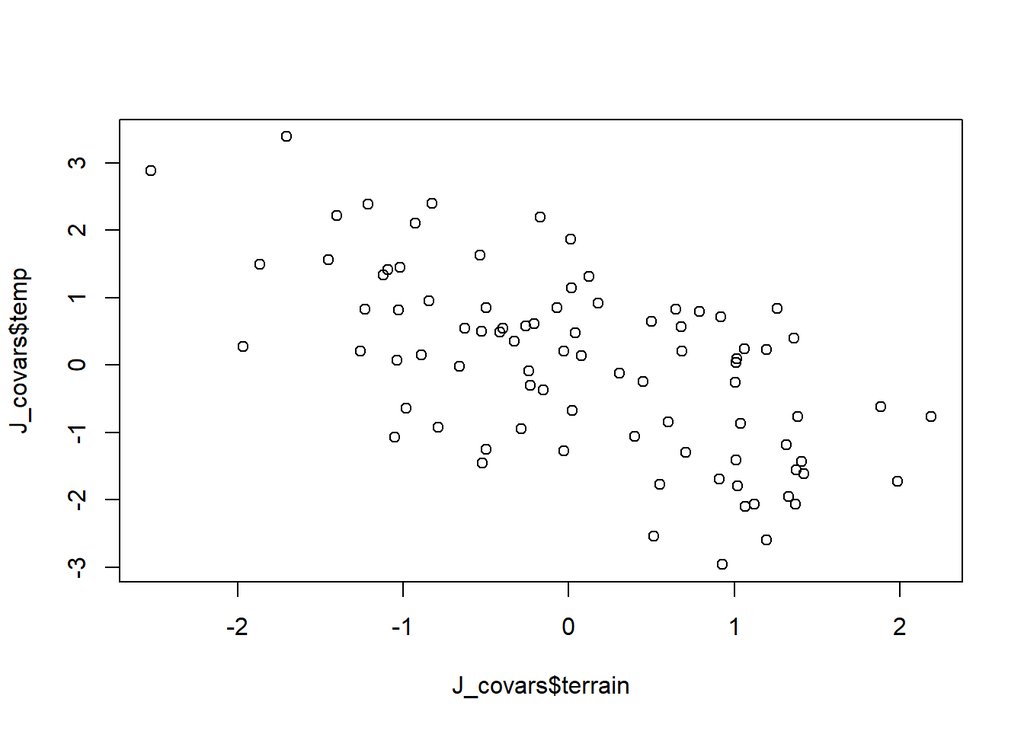

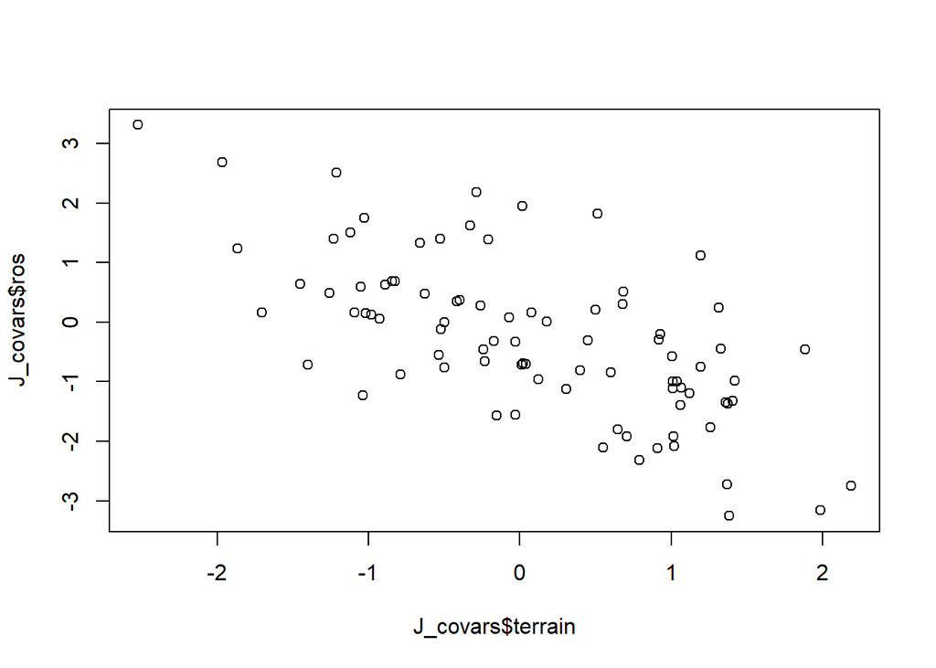

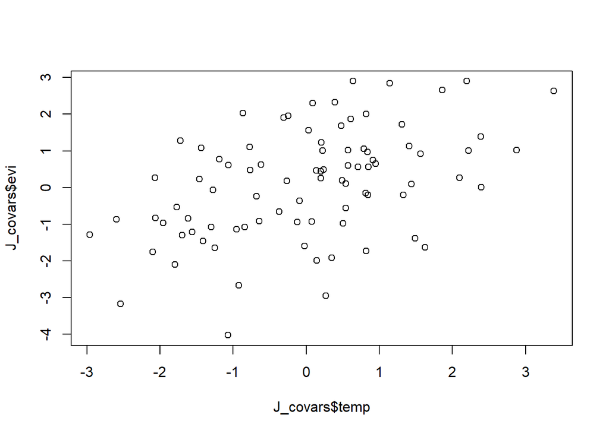

To generate our occurrence probabilities, $\psi$, we use the covariate values above combined with coefficient values for occupancy ($\gamma$).

```r
# Specify coefficient values representing the actual relationships (can use to check accuracy later)
occ_int <- qlogis(0.25) # mean expected occupancy at each site
occ_gamma1 <- -1        # occ dec w/ higher temp
occ_gamma2 <- -2        # occ dec w/ higher ros
occ_gamma3 <- 1.5       # occ inc w/ higher evi

# Randomly generate occurrence probabilities using plogis (distribution function)
psi <- plogis(occ_int + occ_gamma1 * J_covars$temp +
                occ_gamma2 * J_covars$ros + occ_gamma3 * J_covars$evi)
```

Which will look like the following:

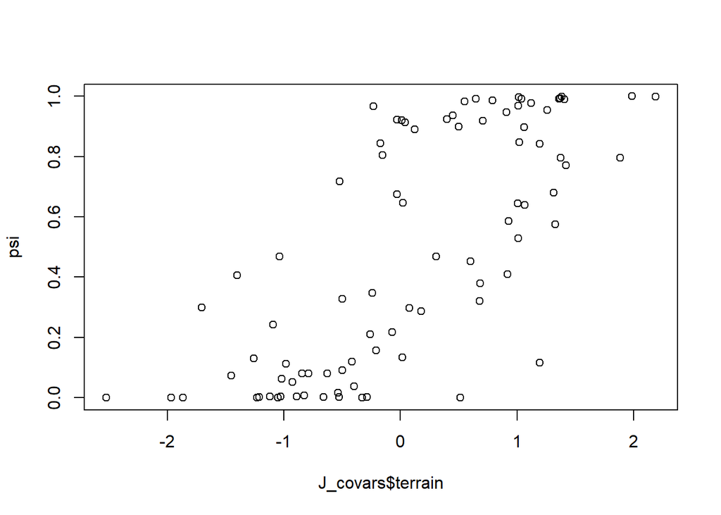

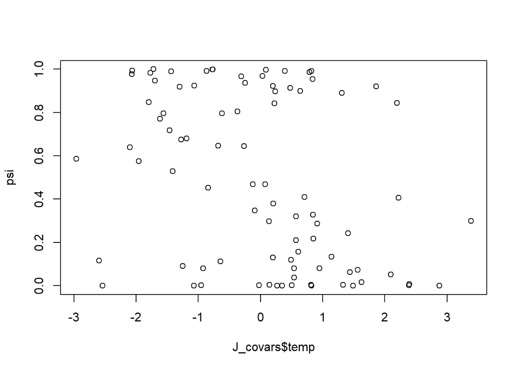

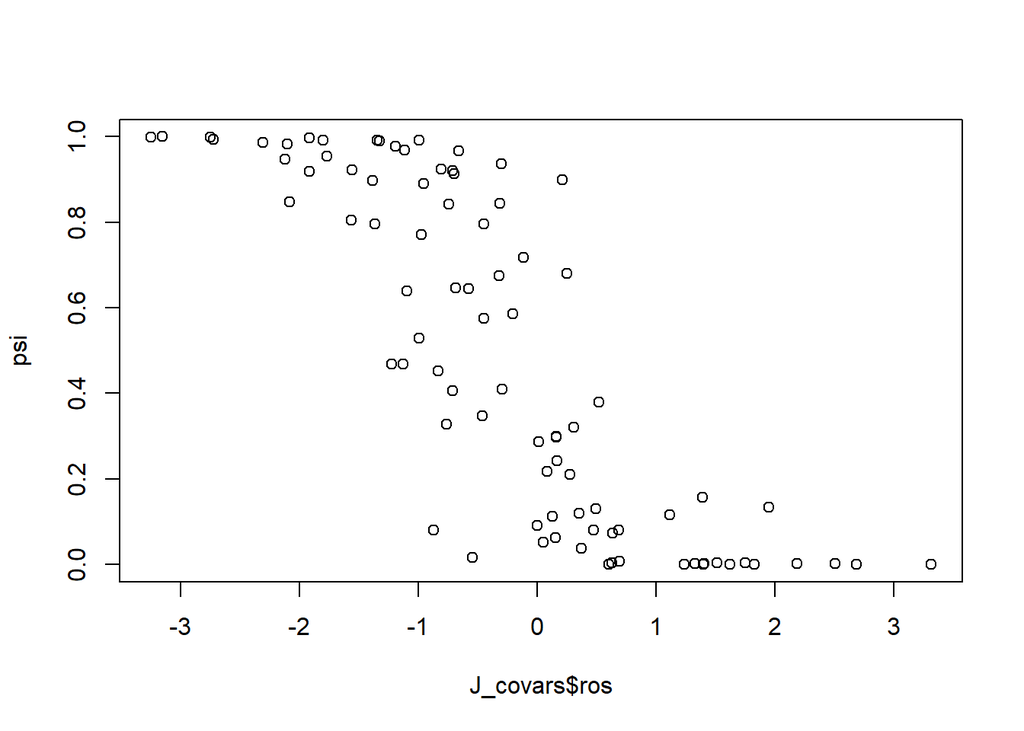

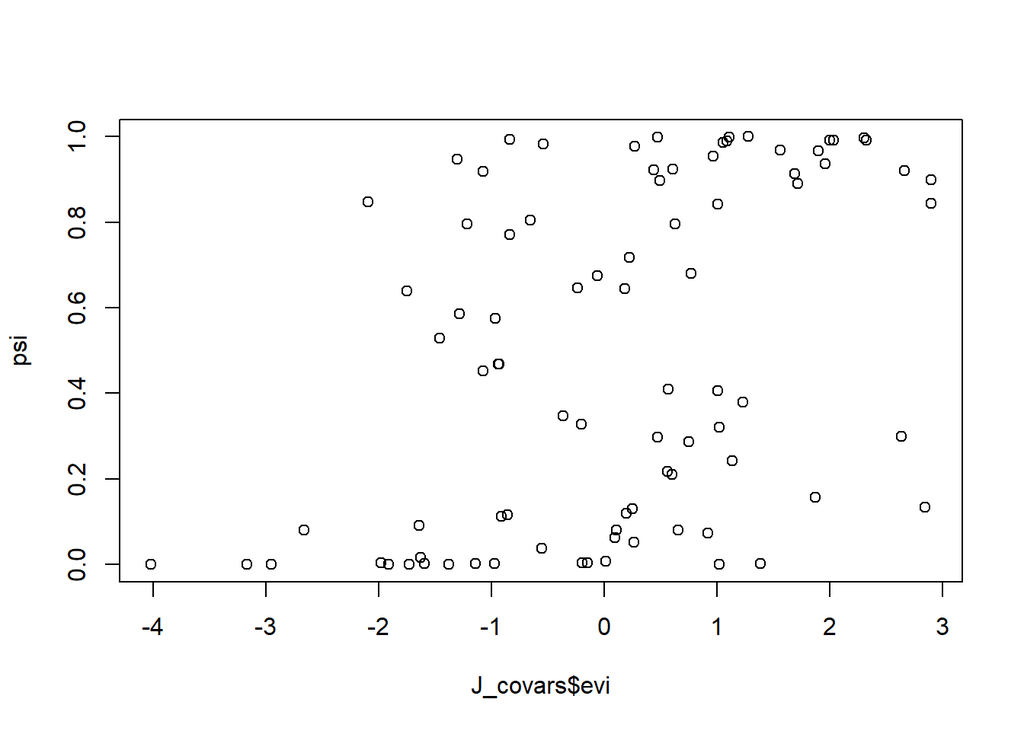

And we can specify detection probabilities for each type of detection.

```r
# Specify the detection probabilities for each type of detection
det_int <- as.vector(NA) # creates an empty vector
det_int[1] <- 0.3        # detection type: scat
det_int[2] <- 0.1        # detection type: haypiles
det_int[3] <- 0.4        # detection type: vocalizations
det_int[4] <- 0.01       # detection type: individual sightings
```

#### Simulate our data

Once we have generate covariates and coefficients for our data, we can use them to generate data to feed into our model. Here, we are creating a matrix of detections and simulating detection histories for our four types of detections given the true occupancy state for each site.

```r
# Create a matrix of detections
p <- matrix(NA, nrow = J, ncol = K) # site occupancy
for(j in 1:K){
  p[, j] <- det_int[j]
}

# Simulate detection histories
Z <- vector()
for(i in 1:J){
  Z[i] <- rbinom(1, 1, psi[i]) # true occupancy state for each site
}
y <- matrix(NA, nrow = J, ncol = K) # empty matrix for simulated detections
for(i in 1:J){
  for(j in 1:K){
    y[i, j] <- Z[i]*rbinom(1,1,p[i, j])
  }
}
```

If we look at a snapshot of the detection history, it shows a matrix of 1’s and 0’s for each site and each type of detection. This is our simulated data.

[output not shown]

And, as the last step before writing our model, we can define our prior distributions. Here, we show some example prior distributions.

```r
res <- 100
x <- seq(-3,3, length.out = res)
n <- 1000

beta0 <- rlogis(n, 0, 1)         # create a uniform distribution
beta1 <- rnorm(n, -0.25, 0.15)   # distribution centered around 0.43

# View an example histogram of the distribution before and after logit transformation
hist(beta0)
hist(plogis(beta1))


# Make an empty matrix
prior <- matrix(NA, n, res)

# Generate a distribution from -3 to 3
for (j in 1:res){
  prior[,j] <- beta0 + beta1 * x[j]
}

# View example of a weakly informative prior distribution
boxplot(plogis(prior), names = round(x,digits = 1), outline = F)
```

[output not shown]

### Coding the structural equation occupancy model

Once our data is simulated, we can fit them to our model. As a reminder, our path equations are as follows:

$$\begin{align*}
temp_{i} &\sim a_{1}terrain_{i} \\
ros_{i} &\sim a_{2}terrain_{i} \\
evi_{i} &\sim a_{3}terrain_{i} + a_{4}temp_{i}\\
\psi &\sim \gamma_{0} + \gamma_{1}temp_{i} + \gamma_{2}ros_{i} +
\gamma_{3}evi_{i}
\end{align*}$$

To do this, we sink the model to JAGS with our JAGS interface package, “jagsUI”, then define our priors and likelihood equations. For this example, we coded the following structural equation occupancy model.

*Note, the occupancy model is hierarchically nested within the likelihood equations as separate occupancy and detection models. Within our detection model, we listed our detection types, $b0$, as a vector with 4 different prior distributions (all uniform in this case).

```r
# Structural equation occupancy model
sink("SEMOcc_Simulation.jags")
cat("

model{
  # Priors
  a1 ~ dnorm(-0.25,0.15)  # temp ~ a1*terrain
  a2 ~ dlogis(0,1)        # ros ~ a2*terrain
  a3 ~ dlogis(0,1)        # evi ~ a3*terrain + a4*temp
  a4 ~ dlogis(0,1)        # evi ~ a3*terrain + a4*temp

  b0[1] ~ dlogis(0,1)     # scat
  b0[2] ~ dlogis(0,1)     # hapyiles
  b0[3] ~ dlogis(0,1)     # vocalizations
  b0[4] ~ dlogis(0,1)     # individual sightings

  g0 ~ dlogis(0,1)        # psi ~ intercept
  g1 ~ dnorm(0.3, 0.5)    # psi ~ temp
  g2 ~ dnorm(0.25,0.15)   # psi ~ ros
  g3 ~ dnorm(0.25,0.15)   # psi ~ evi

  for (k in 1:3){
    sigma[k] ~ dgamma(1,1)
    tau[k] = 1/(sigma[k] * sigma[k])
  }

  for (j in 1:4){
    # p[j] ~ dbeta(1,1)
    logit(p[j]) = b0[j]
  }

  # Likelihood
  for(i in 1:J){

    # model for temperature given terrain (no intercept bc covariates 0 centered)
    temp[i] ~ dnorm(a1*terrain[i], tau[1])

    # model for rain on snow given terrain
    ros[i] ~ dnorm(a2*terrain[i], tau[2])

    # model for evi given terrain and temperature
    evi[i] ~ dnorm(a3*terrain[i] + a4*temp[i], tau[3])

    # model for occupancy given temperature, rain on snow, and EVI
    Z[i] ~ dbern(psi[i]) # Z = 1 if true state occupied
    logit(psi[i]) <- g0 + g1*temp[i] + g2*ros[i] + g3*evi[i]

    # model for detection
    for(j in 1:K){
      y[i,j] ~ dbern(Z[i]*p[j])
      # logit(p[i,j]) <- b0[j] # detection equation
    }
  }

  # Derived variable
  N <- sum(Z)
}
",fill = TRUE)
sink()
```

Once the model is written, we can specify our initial values and run the model with our simulated data, as follows.

```r
# Organize the simulated data
jags_data = list(J = J, K = K, y = y, Z = ifelse(rowSums(y) > 0, 1, NA),
                 terrain = J_covars$terrain, temp = J_covars$temp,
                 ros = J_covars$ros, evi = J_covars$evi)

params = c('a1', 'a2', 'a3', 'a4', 'g0', 'g1', 'g2', 'g3', 'N', 'Z', 'p') # parameters to save from model

inits <- function() {   # specify initial values
  a1 <- rnorm(1, 0, .5)
  a2 <- rnorm(1, 0, .5)
  a3 <- rnorm(1, 0, .5)
  a4 <- rnorm(1, 0, .5)
  b0 <- rnorm(4, 0, .5)

  return(list(a1 = a1, a2 = a2, a3 = a3, a4 = a4,
              b01 = b0[1], b02 = b0[2], b03 = b0[3], b04 = b0[4]))
}

# Run the model
occ_sim <- jagsUI::jags(data = jags_data,
                        inits=inits,
                        model.file = "SEMOcc_Simulation.jags",
                        parameters.to.save = params,
                        n.chains = 25,              # chains to run
                        n.iter = 15000,             # iterations including burn in
                        n.thin = 10,                # thinning rate
                        parallel = T)
```

And we can look at the results and diagnostic plots.

```r
summary(occ_sim) # summary of model
```

```
## Summary for model 'SEMOcc_Simulation.jags'
## Saved parameters: a1 a2 a3 a4 g0 g1 g2 g3 N Z p deviance
## MCMC ran in parallel for 0.879 minutes at time 2024-02-13 14:11:00.
##
## For each of 25 chains:
## Adaptation:            100 iterations (sufficient)
## Burn-in:               0 iterations
## Thin rate:             10 iterations
## Total chain length:    15100 iterations
## Posterior sample size: 1500 draws
##
## Successful convergence based on Rhat values (all < 1.1).
##
## DIC info: (pD = var(deviance)/2)
## pD = 35.3 and DIC = 933.505
```

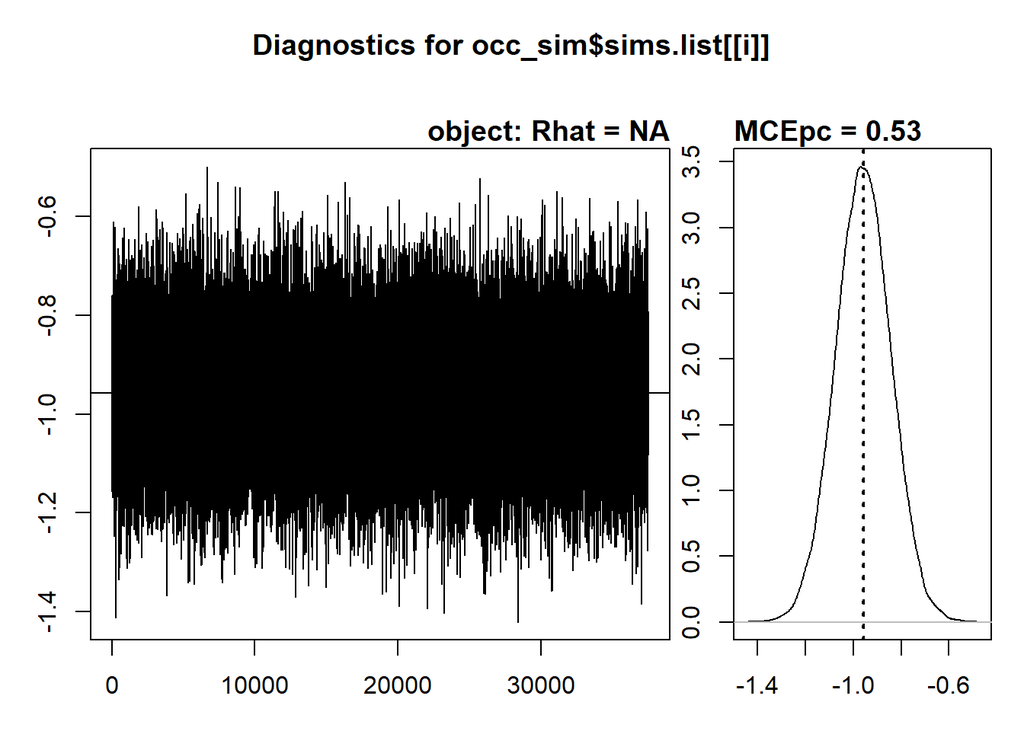

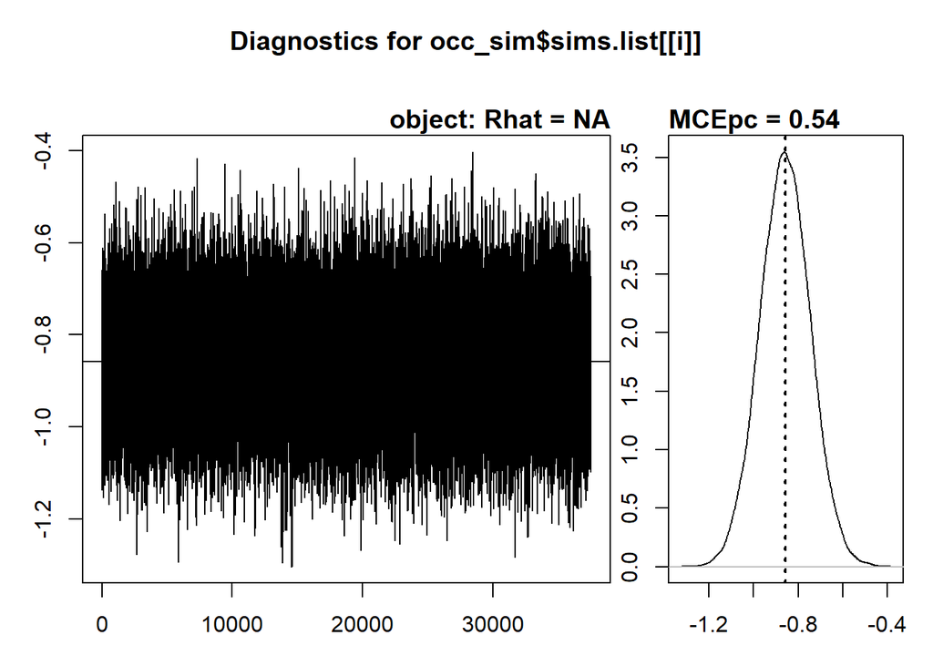

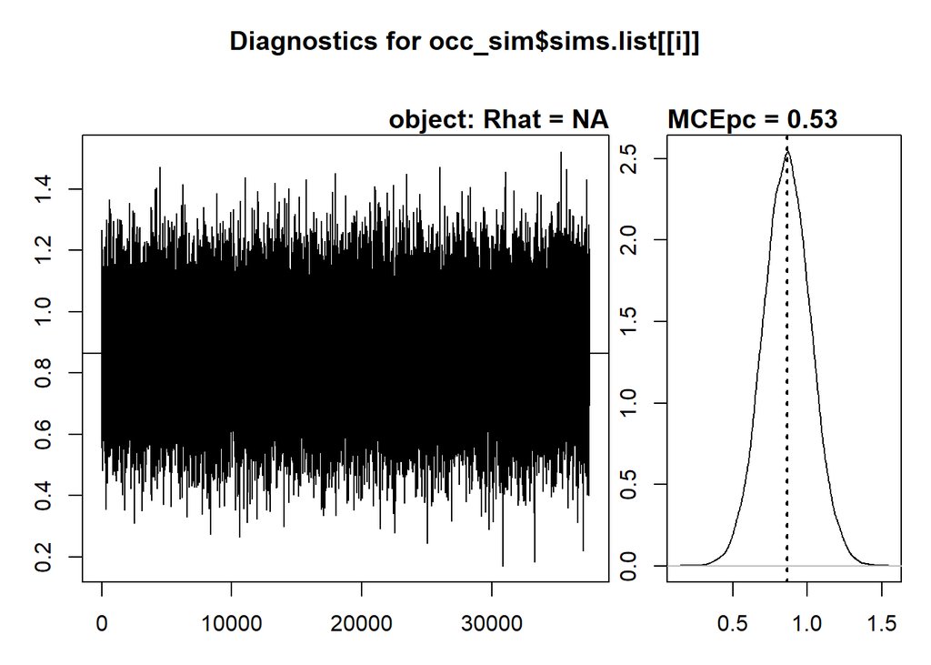

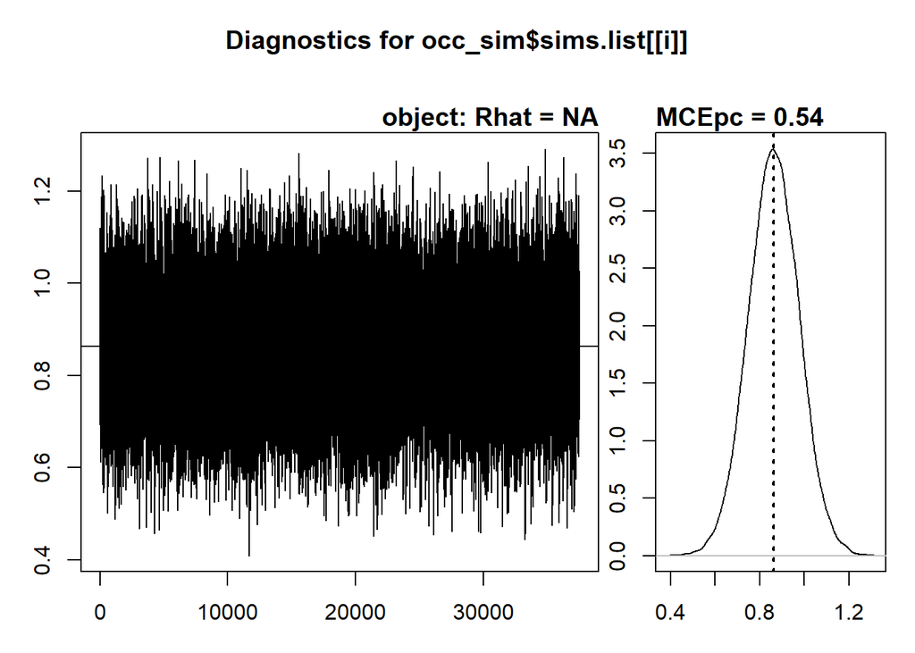

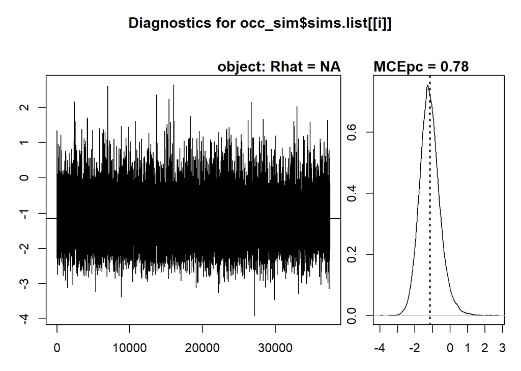

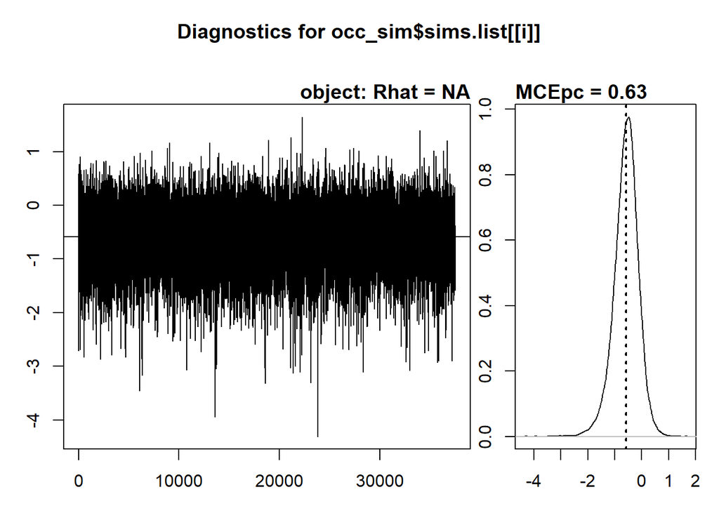

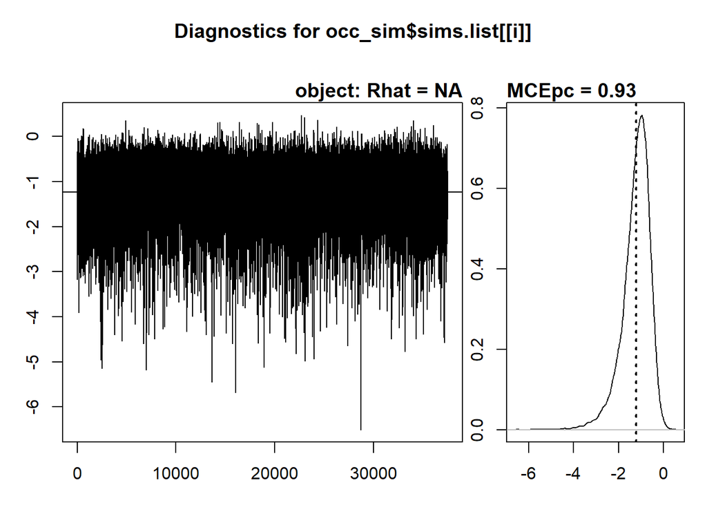

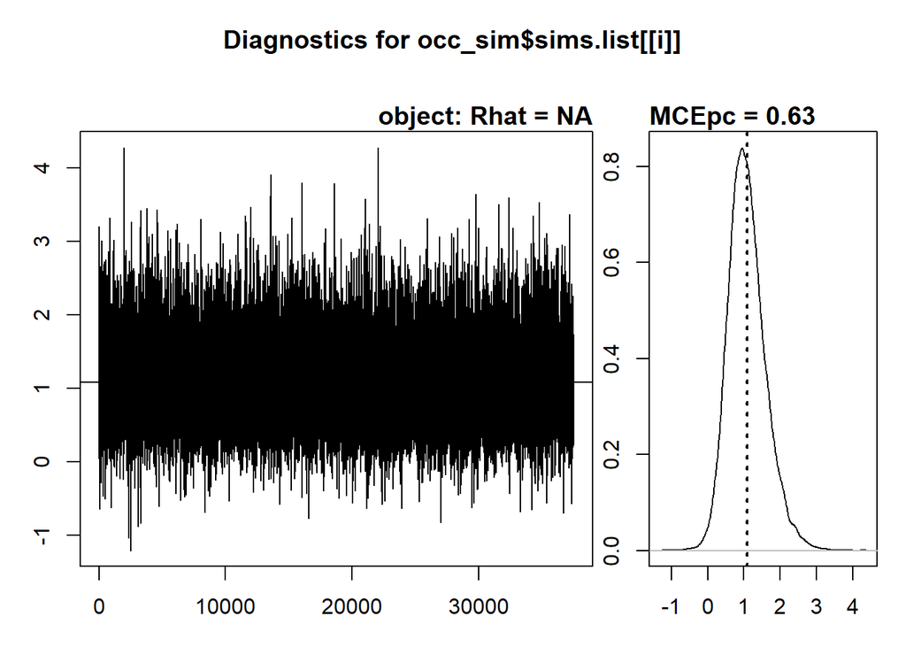

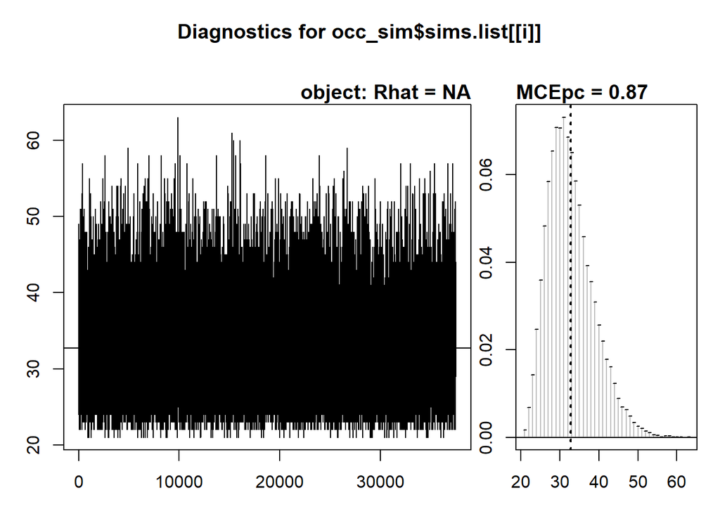

```r
# View diagnostic plots for a, gamma, and p
for(i in 1:9){
  mcmcOutput::diagPlot(occ_sim$sims.list[[i]]) # view diagnostic plots
}
```

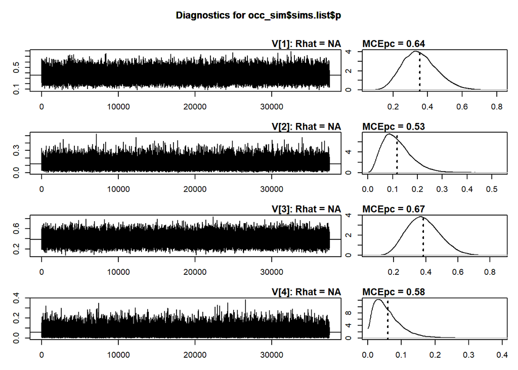

```r
mcmcOutput::diagPlot(occ_sim$sims.list$p)      # view diagnostic plots for p
```

And the full printed summary of the model, which we can use to compare to our original inputs.

```r
print(occ_sim)
```

```
## JAGS output for model 'SEMOcc_Simulation.jags', generated by jagsUI.
## Estimates based on 25 chains of 15000 iterations,
## adaptation = 100 iterations (sufficient),
## burn-in = 0 iterations and thin rate = 10,
## yielding 37500 total samples from the joint posterior.
## MCMC ran in parallel for 0.879 minutes at time 2024-02-13 14:11:00.
##
##             mean    sd    2.5%     50%   97.5% overlap0     f  Rhat n.eff
## a1        -0.958 0.115  -1.185  -0.958  -0.732    FALSE 1.000 1.000 37500
## a2        -0.858 0.113  -1.080  -0.858  -0.634    FALSE 1.000 1.000 32020
## a3         0.863 0.159   0.549   0.863   1.178    FALSE 1.000 1.000 37500
## a4         0.863 0.113   0.639   0.862   1.086    FALSE 1.000 1.000 37500
## g0        -1.151 0.591  -2.219  -1.187   0.140     TRUE 0.965 1.001 14687
## g1        -0.585 0.459  -1.581  -0.558   0.254     TRUE 0.917 1.000 22750
## g2        -1.231 0.622  -2.750  -1.134  -0.299    FALSE 0.997 1.001 10483
## g3         1.085 0.515   0.197   1.040   2.218    FALSE 0.992 1.000 35984
## N         32.743 5.867  24.000  32.000  46.000    FALSE 1.000 1.001 13431
## Z[1]       0.491 0.500   0.000   0.000   1.000     TRUE 1.000 1.000 27274
## Z[2]       0.483 0.500   0.000   0.000   1.000     TRUE 1.000 1.000 37500
## Z[3]       0.529 0.499   0.000   1.000   1.000     TRUE 1.000 1.000 21360
## Z[4]       1.000 0.000   1.000   1.000   1.000    FALSE 1.000    NA     1
## Z[5]       1.000 0.000   1.000   1.000   1.000    FALSE 1.000    NA     1
## Z[6]       0.333 0.471   0.000   0.000   1.000     TRUE 1.000 1.000 23358
## Z[7]       0.028 0.164   0.000   0.000   1.000     TRUE 1.000 1.000 37500
## Z[8]       0.033 0.177   0.000   0.000   1.000     TRUE 1.000 1.000 34773
## Z[9]       0.187 0.390   0.000   0.000   1.000     TRUE 1.000 1.000 28607
## Z[10]      0.064 0.244   0.000   0.000   1.000     TRUE 1.000 1.001 22414
## Z[11]      0.107 0.309   0.000   0.000   1.000     TRUE 1.000 1.000 33996
## Z[12]      0.687 0.464   0.000   1.000   1.000     TRUE 1.000 1.000 29588
## Z[13]      0.105 0.307   0.000   0.000   1.000     TRUE 1.000 1.000 37500
## Z[14]      0.012 0.109   0.000   0.000   0.000    FALSE 1.000 1.001 37500
## Z[15]      0.092 0.289   0.000   0.000   1.000     TRUE 1.000 1.000 26048
## Z[16]      0.500 0.500   0.000   1.000   1.000     TRUE 1.000 1.000 30663
## Z[17]      0.374 0.484   0.000   0.000   1.000     TRUE 1.000 1.000 19761
## Z[18]      0.171 0.377   0.000   0.000   1.000     TRUE 1.000 1.000 37500
## Z[19]      0.357 0.479   0.000   0.000   1.000     TRUE 1.000 1.001 13817
## Z[20]      1.000 0.000   1.000   1.000   1.000    FALSE 1.000    NA     1
## Z[21]      1.000 0.000   1.000   1.000   1.000    FALSE 1.000    NA     1
## Z[22]      0.879 0.326   0.000   1.000   1.000     TRUE 1.000 1.000 24314
## Z[23]      0.034 0.182   0.000   0.000   1.000     TRUE 1.000 1.000 33071
```

[output cut: 65 more lines]

```
## p[3]       0.385 0.102   0.204   0.378   0.599    FALSE 1.000 1.000 28440
## p[4]       0.059 0.042   0.007   0.050   0.165    FALSE 1.000 1.000 21445
## deviance 898.192 8.406 881.932 898.162 915.007    FALSE 1.000 1.000 22321
##
## Successful convergence based on Rhat values (all < 1.1).
## Rhat is the potential scale reduction factor (at convergence, Rhat=1).
## For each parameter, n.eff is a crude measure of effective sample size.
##
## overlap0 checks if 0 falls in the parameter's 95% credible interval.
## f is the proportion of the posterior with the same sign as the mean;
## i.e., our confidence that the parameter is positive or negative.
##
## DIC info: (pD = var(deviance)/2)
## pD = 35.3 and DIC = 933.505
## DIC is an estimate of expected predictive error (lower is better).
```